# 105.3. Forced photometry

For the Rubin Science Platform at data.lsst.cloud.  
Data Release: [Data Preview 2](https://dp2.lsst.io/)  
Container Size: Large  
LSST Science Pipelines version: r30.0.11  
Last verified to run: 2026-11-16  
Repository: github.com/lsst/tutorial-notebooks  
DOI: 10.11578/rubin/dc.20250909.20

**Learning objective:** Make forced measurements on an image for a set of coordinates.

**LSST data products:** `deep_coadd`, `Object` table

**Packages:** `lsst.pipe.tasks`, `lsst.daf.butler`

**Credit:** Originally developed by the Rubin Community Science team working with Erfan Nourbakhsh. Please consider acknowledging them if this notebook is used for the preparation of journal articles, software releases, or other notebooks.

**Get Support:** Everyone is encouraged to ask questions or raise issues in the [Support Category](https://rubin.community/c/support) of the Rubin Community Forum. Rubin staff will respond to all questions posted there.

> **Warning:** This tutorial makes use of an `ExposureF` object because the pipeline tasks being demonstrated currently require this. However, `ExposureF` objects are being deprecated in favor of `lsst.images` objects (https://images.lsst.io/).

## 1. Introduction

In general, "forced" photometry refers to a measurement made at a fixed coordinate in an image, regardless of whether an above-threshold (SNR $>5$) source was detected at that location in that particular image. Forced photometry uses the point-spread-function (PSF) of the image, and measures the flux assuming the shape and size of the PSF at the provided coordinates.

This notebook performs forced photometry using the Data Preview 2 (DP2) data products on an input image, given a set of input coordinates (RA/Dec).

The `ForcedMeasurementDriverTask` serves as a convenience function, allowing users to measure sources without running a full-scale `pipetask` command or dealing with additional pipeline setup. This task can measure fluxes, shapes, and other properties at known source positions (e.g., from a pre-existing catalog) on a given image, without running source detection. For brevity, shape measurement is disabled in this tutorial.

**Related tutorials:** The 100-level tutorial on how to detect and measure sources, which was used to create the input file of sub-threshold detections used later in this tutorial. The 200-level tutorials on the PSF.

### 1.1. Import packages

Import standard python packages `numpy`, `matplotlib`, and `astropy`.

From the `lsst` package, import the TAP service (`RSPDiscovery`) and the `Butler` for data access, and `ForcedMeasurementDriverConfig` and `ForcedMeasurementDriverTask`: mid-level configuration and task classes used to set up and execute forced photometry.

```python
import matplotlib.pyplot as plt
import numpy as np
import astropy.units as u
from astropy.table import Table

from lsst.rsp import RSPDiscovery
from lsst.daf.butler import Butler
from lsst.pipe.tasks.measurementDriver import (
    ForcedMeasurementDriverConfig,
    ForcedMeasurementDriverTask,
)
```

### 1.2. Define parameters and functions

Create an instance of the butler, and assert that it exists.

```python
butler = Butler("dp2", collections="dp2")
assert butler is not None
```

Instantiate the TAP service and assert that it exists.

```python
discovery = RSPDiscovery("dp2")

service = discovery.get_tap_client()

assert service is not None
```

Create a function called `fix_flux_columns` to rename output columns from the forced measurement task that are incorrectly labeled as instrument fluxes, when they are in fact not instrumental (i.e., in units of counts) but are calibrated fluxes in units of nJy. This mistake will be fixed in future versions of the LSST Science Pipelines.

```python
def fix_flux_columns(table):
    """Rename the columns in an output table from the ForcedMeasurementDriverTask.

    This task is necessary to rename "instFlux" columns to "flux" and units from
    "ct" to "nJy".

    Parameters
    ----------
    table : Astropy Table
        An Astropy table resulting from executing the ForcedMeasurementDriver

    Outputs
    -------
    table : Astropy Table
        Transformed version of the input table, with columns and units updated.
    """

    cols_with_instflux = [col for col in np.array(table.colnames) if 'instFlux' in col]

    for col in cols_with_instflux:
        new_colname = str.replace(col, 'instFlux', 'flux')
        table.rename_column(col, new_colname)
        table[new_colname].unit = u.nJy

    return table
```

## 2. Measure objects in a deep coadd

**Note:** The fluxes in the `Object` catalog are already forced photometry measurements, and re-measuring them is not necessary for scientific analysis. The `Object` table is just used to get a set of coordinates for this tutorial.

### 2.1. Load an image and catalog

Identify coadded images overlapping a particular sky position and select one to run forced photometry on. Also load the corresponding `Object` table using the TAP service so that forced photometry can be run at the positions of already-detected objects.

Adopt Right Ascension and Declination values near the center of the ECDFS field, and use the $r$ band.

```python
ra = 53.1
dec = -28.1
band = 'r'
```

Execute a butler query for deep coadd images.

```python
query = f"band='{band}' AND \
          patch.region OVERLAPS POINT({ra}, {dec})"
coadd_img_refs = butler.query_datasets('deep_coadd', where=query,
                                       order_by='patch')
```

Assert that at least one matching image was returned. Retrieve the first in the sorted list.

```python
assert len(coadd_img_refs) > 0
ref = coadd_img_refs[0]
deep_coadd = butler.get(ref)
```

Query for point-like objects from the `Object` table in a 0.3 degree radius near the position of interest that overlap the deep coadd image's tract and patch.

```python
query = f"""SELECT TOP 50 objectId, coord_ra, coord_dec, {band}_psfMag, {band}_psfFlux
        FROM dp2.Object
        WHERE CONTAINS(POINT('ICRS', coord_ra, coord_dec), CIRCLE('ICRS', {ra}, {dec}, 0.3)) = 1
        AND refExtendedness < 0.5
        AND {band}_psfMag < 26 AND {band}_psfMag > 17
        AND tract = {ref.dataId['tract']}
        AND patch = {ref.dataId['patch']}"""

job = service.submit_job(query)
job.run()
job.wait(phases=['COMPLETED', 'ERROR'])
print('Job phase is', job.phase)
if job.phase == 'ERROR':
    job.raise_if_error()
```

```
Job phase is COMPLETED
```

Retrieve the search results as `objtable`. This table will be used both as an input list for forced measurement, and as a comparison for the results.

```python
assert job.phase == 'COMPLETED'
objtable = job.fetch_result().to_table()
```

Assert that the `objtable` is not empty.

```python
assert len(objtable) > 0
```

Option to display the `objtable`.

```python
# objtable
```

### 2.2. Run the forced measurement driver

Configure the forced measurement driver to use `base_PsfFlux` as the algorithm for the PSF flux slot, and `base_TransformedCentroidFromCoord` for centroids transformed from the reference catalog. Set other config parameters to disable shape measurement and avoid replacing other detected footprints with noise. These are simply examples of how to set configuration options, and are not required to run the task. Aperture corrections are not applied by the driver, because the `ExposureF` version of a cell-based coadd, which the driver requires, cannot carry the cell coadd’s aperture corrections. The corrections themselves are available from the `CellCoadd` (in its `aperture_corrections` attribute), and could be evaluated at each source’s position and applied to the forced fluxes after measurement.

*Note:* *`base_PsfFlux` and `base_TransformedCentroidFromCoord` are included by default in the measurement plugins, so there's no need to add them manually to `config.measurement.plugins.names`. They’ll be picked up automatically.*

```python
config = ForcedMeasurementDriverConfig()
config.measurement.slots.psfFlux = "base_PsfFlux"
config.measurement.slots.centroid = "base_TransformedCentroidFromCoord"
config.measurement.slots.shape = None
config.measurement.doReplaceWithNoise = False
```

Option to examine the configuration.

```python
# config
```

Create the forced photometry driver task using the configuration.

```python
driver = ForcedMeasurementDriverTask(config=config)
```

`ForcedMeasurementDriverTask` requires the image to be of type `ExposureF`, so convert the deep coadd to type `ExposureF` here. However, users should in general use `lsst.images` image formats whenever possible rather than `ExposureF`.

```python
legacy_coadd = deep_coadd.to_legacy()
```

Run the task using the input table of source positions and IDs, the `legacy_coadd` image, and required parameters: column names for ID, RA, and Dec, plus a PSF footprint scaling factor (used to create synthetic footprints since detection is skipped in forced photometry).

```python
result = driver.runFromAstropy(
    objtable,
    legacy_coadd,
    id_column_name="objectId",
    ra_column_name="coord_ra",
    dec_column_name="coord_dec",
    psf_footprint_scaling=3.0,
)
```

```
lsst.forcedMeasurementDriver INFO: Measuring 50 sources in a single band using 'ForcedMeasurementTask'
```

```
lsst.forcedMeasurementDriver.measurement INFO: Performing forced measurement on 50 sources
```

```
lsst.forcedMeasurementDriver INFO: Finished processing for a single band; output catalog has 85 fields and 50 records
```

Because the `ForcedMeasurementDriverTask` relies on code that is typically used in early stages of data processing, it assumes that fluxes are instrumental fluxes and appends the suffixes `_instFlux` and `_instFluxErr` to the output columns. It also sets the units for these columns to "ct" (counts).

However, these assumptions about the types of fluxes are incorrect when running this task on calibrated visit and deep coadd images, whose pixel values are in nJy.

Confirm that the pixel values are in units of nJy.

```python
deep_coadd.unit
```

$\mathrm{nJy}$

Use the function defined in Section 1.2 to fix the column names. This step is temporary as the column names will be fixed in the future.

```python
result = fix_flux_columns(result)
```

Examine the resulting Astropy table containing the measured sources. Each row corresponds to a record from the input table, with columns for source ID, RA, and Dec, along with additional measurement fields defined by the configuration.

```python
result[:5]
```

*Table length=5*

| coord_ra rad float64 | coord_dec rad float64 | parent int64 | objectId int64 | parentObjectId int64 | deblend_nChild int32 | base_TransformedCentroidFromCoord_x pix float64 | slot_Centroid_x pix float64 | base_TransformedCentroidFromCoord_y pix float64 | slot_Centroid_y pix float64 | base_CircularApertureFlux_3_0_flux nJy float64 | base_CircularApertureFlux_3_0_fluxErr nJy float64 | base_CircularApertureFlux_3_0_flag bool | base_CircularApertureFlux_3_0_flag_apertureTruncated bool | base_CircularApertureFlux_3_0_flag_sincCoeffsTruncated bool | base_CircularApertureFlux_4_5_flux nJy float64 | base_CircularApertureFlux_4_5_fluxErr nJy float64 | base_CircularApertureFlux_4_5_flag bool | base_CircularApertureFlux_4_5_flag_apertureTruncated bool | base_CircularApertureFlux_4_5_flag_sincCoeffsTruncated bool | base_CircularApertureFlux_6_0_flux nJy float64 | base_CircularApertureFlux_6_0_fluxErr nJy float64 | base_CircularApertureFlux_6_0_flag bool | base_CircularApertureFlux_6_0_flag_apertureTruncated bool | base_CircularApertureFlux_6_0_flag_sincCoeffsTruncated bool | base_CircularApertureFlux_9_0_flux nJy float64 | base_CircularApertureFlux_9_0_fluxErr nJy float64 | base_CircularApertureFlux_9_0_flag bool | base_CircularApertureFlux_9_0_flag_apertureTruncated bool | base_CircularApertureFlux_9_0_flag_sincCoeffsTruncated bool | … |
| --- | --- | --- | --- | --- | --- | --- | --- | --- | --- | --- | --- | --- | --- | --- | --- | --- | --- | --- | --- | --- | --- | --- | --- | --- | --- | --- | --- | --- | --- | --- |
| 0.9294947549469645 | -0.49092510675066225 | 0 | 755369573523392182 | 0 | 0 | 12322.95630933277 | 12322.95630933277 | 4065.7753885797774 | 4065.7753885797774 | 108.91565704345703 | 21.735374450683594 | False | False | False | 128.52635192871094 | 32.70494842529297 | False | False | False | 192.19970703125 | 43.78263854980469 | False | False | False | 176.27334594726562 | 66.03450775146484 | False | False | False | … |
| 0.9276529904199908 | -0.4909290195078257 | 0 | 755369573523392174 | 0 | 0 | 13998.182137986985 | 13998.182137986985 | 4063.335988157336 | 4063.335988157336 | 215.65512084960938 | 24.409852981567383 | False | False | False | 356.0856018066406 | 36.46016311645508 | False | False | False | 418.28778076171875 | 48.847991943359375 | False | False | False | 420.7357177734375 | 72.64543151855469 | False | False | False | … |
| 0.9285272815803919 | -0.4909529509090676 | 0 | 755369573523392145 | 0 | 0 | 13202.97356352795 | 13202.97356352795 | 4038.0757107004356 | 4038.0757107004356 | 87.92168426513672 | 22.118722915649414 | False | False | False | 135.82391357421875 | 33.32065200805664 | False | False | False | 139.2987060546875 | 44.69348907470703 | False | False | False | 208.1266632080078 | 67.37799835205078 | False | False | False | … |
| 0.9276431262771949 | -0.49089706930719057 | 0 | 755369573523392218 | 0 | 0 | 14007.137677745844 | 14007.137677745844 | 4096.295336045192 | 4096.295336045192 | 167.11087036132812 | 22.148574829101562 | False | False | False | 249.91323852539062 | 33.20283508300781 | False | False | False | 265.0390930175781 | 44.45890426635742 | False | False | False | 281.19549560546875 | 67.0239486694336 | False | False | False | … |
| 0.9266656075394462 | -0.490918412694609 | 0 | 755369573523392193 | 0 | 0 | 14896.276572770686 | 14896.276572770686 | 4074.5331401796047 | 4074.5331401796047 | 203.54505920410156 | 22.796859741210938 | False | False | False | 289.38671875 | 34.07534408569336 | False | False | False | 385.1264343261719 | 45.67351531982422 | False | False | False | 479.4609069824219 | 68.83203887939453 | False | False | False | … |

The table now includes PSF fluxes (`base_psfFlux_flux`) and aperture fluxes (e.g., `base_CircularApertureFlux_3_0_flux` for a 3-pixel aperture), among many other columns.

Most of the output columns are similar to columns that exist in the `Source` table -- refer to the [schema for the DP2 Source table](https://sdm-schemas.lsst.io/dp2.html#Source) and the 200-level tutorial notebook on the `Source` catalog for descriptions.

Each flux measurement has an associated flux error and one or more flag columns to allow filtering of bad measurements. Additionally, there are many pixel-based flags (denoted `base_PixelFlags_*`) highlighting possible issues with the data for each source.

Columns that begin with `slot_` are duplicates of other columns in the table. These exist as a way of telling algorithms in the Science Pipelines which is the "preferred" measurement for things like positions, shapes, and fluxes. Because there are multiple ways of measuring shapes (for example), this lets processing algorithms know which of these to select. Note that the specific measurements populating (some of) the slots were configured above, for example `config.measurement.slots.psfFlux = "base_PsfFlux"` was specified.

The forced measurement functionality is limited to a handful of measurement plugins (for example, model-fitting algorithms will not work with this task because they require more ancillary information than it is set up to receive). Nonetheless, it offers a quick and easy way to extract measurements at arbitrary positions.

### 2.3. Compare forced measurements to the Object table

Make a plot showing the ratio of the measured PSF fluxes from the forced measurement task to the `psfFlux` for the same objects in the `Object` table. Plot these as a function of magnitude, using Astropy units to convert `slot_PsfFlux_flux` from the `result` table to AB magnitudes.

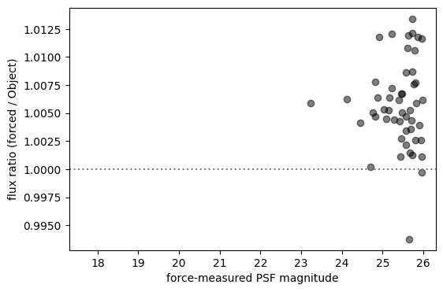

```python
meas_mag = (result['slot_PsfFlux_flux'].value*u.nJy).to(u.ABmag)

fig, ax = plt.subplots(figsize=(6, 4))
ax.plot(meas_mag, result['slot_PsfFlux_flux']/objtable['r_psfFlux'],
        'o', alpha=0.5, mew=1, mec='black', color='black')
ax.hlines(1.0, 17.3, 26.3, linestyle=':', color='gray')
ax.set_xlim(17.3, 26.3)
ax.set_xlabel('force-measured PSF magnitude')
ax.set_ylabel('flux ratio (forced / Object)')
plt.show()
```

> **Figure 1:** The flux ratio of the force-measured PSF flux divided by the PSF flux from the `Object` table, vs. the force-measured PSF magnitude (all for $r$-band).

Delete the catalogs from memory.

```python
del objtable, result
```

## 3. Measurements for user-specified coordinates

Often, the motivation for doing forced photometry is to make forced measurements at a set of coordinates where no object or source has been detected with SNR $>5$ in the deep coadd or visit image (i.e., at coordinates that are not in the `Object` or `Source` tables).

These coordinates might be for subthreshold detections (e.g., SNR $<5$) or for detections from other (non-Rubin) surveys, e.g., infrared, space-based.

For this demonstration, a prepared input file of coordinates is loaded, and then forced photometry is run on a deep coadd.

The input file was generated with the detection, deblending, and measurement 105-series tutorial notebook, by running source detection with `config.thresholdValue = 4` (followed by deblending and measurement) on the same $r$-band deep coadd used in this notebook, and saving the coordinates of all sources in that patch with a PSF flux $4 < SNR < 5$ to the file. Only isolated sources and deblended children were saved; blend parents, which describe a whole blend rather than an individual object, were not. The sub-threshold detection magnitudes were also saved in the file.

Note that some of these coordinates may nonetheless have counterparts in the `Object` table, because the production pipeline detects objects using all bands together, so an object that is sub-threshold in the $r$-band coadd alone can still be detected.

Load the file as an astropy table, add units to the coordinates columns, and print the column names.

```python
filepath = '/rubin/cst_repos/tutorial-notebooks-data/data/'
filename = 'dp2_105_3_subthreshold_deep_coadd.dat'
subthresh = Table.read(filepath+filename, format="ascii")
subthresh["ra"].unit = u.deg
subthresh["dec"].unit = u.deg
print('file columns: ', subthresh.colnames)
print('file length: ', len(subthresh))
```

```
file columns:  ['id', 'ra', 'dec', 'r_mag', 'r_mag_err']
file length:  1337
```

Option to view the loaded table.

```python
# subthresh
```

Run the forced measurement driver with the same configuration as used in Section 2, but pass the `subthresh` table and use column names that match the input file.

```python
config = ForcedMeasurementDriverConfig()
config.measurement.slots.psfFlux = "base_PsfFlux"
config.measurement.slots.centroid = "base_TransformedCentroidFromCoord"
config.measurement.slots.shape = None
config.measurement.doReplaceWithNoise = False

driver = ForcedMeasurementDriverTask(config=config)

src_result = driver.runFromAstropy(
    subthresh,
    legacy_coadd,
    id_column_name="id",
    ra_column_name="ra",
    dec_column_name="dec",
    psf_footprint_scaling=3.0,
)

src_result = fix_flux_columns(src_result)
```

```
lsst.forcedMeasurementDriver INFO: Measuring 1337 sources in a single band using 'ForcedMeasurementTask'
```

```
lsst.forcedMeasurementDriver.measurement INFO: Performing forced measurement on 1337 sources
```

```
lsst.forcedMeasurementDriver INFO: Finished processing for a single band; output catalog has 85 fields and 1337 records
```

Assert that the input and output tables have the same length.

```python
assert len(subthresh) == len(src_result)
```

Option to display the first five lines of the output table.

```python
# src_result[:5]
```

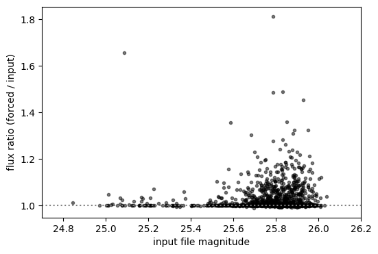

```python
src_result['mag'] = (src_result['slot_PsfFlux_flux'].value*u.nJy).to(u.ABmag)
subthresh['r_flux'] = (subthresh['r_mag'].value*u.ABmag).to(u.nJy)

fig, ax = plt.subplots(figsize=(6, 4))
ax.plot(subthresh['r_mag'], src_result['slot_PsfFlux_flux']/subthresh['r_flux'],
        'o', ms=3, alpha=0.5, mew=1, mec='black', color='black')
ax.hlines(1.0, 24.7, 26.2, linestyle=':', color='gray')
ax.set_xlim(24.7, 26.2)
ax.set_xlabel('input file magnitude')
ax.set_ylabel('flux ratio (forced / input)')
plt.show()
```

> **Figure 2:** The flux ratio of the force-measured PSF flux divided by the PSF flux from the original sub-threshold detection (from the input file) vs. the input file's sub-threshold detection magnitude.